# Heart Project

Luke Austin

2024-03-14

The data set “Heart” comes from https://www.kaggle.com/ronitf/heart-disease-uci. It has info about patients and whether or not they have heart disease. The variable target is 1 if the patient has heart disease and 0 if they do not. The data was split into a training and test set ahead of time. Use the training data to find a logistic regression model that has a high prediction accuracy for predicting the presence/absence of heart disease on the training data. Use your model to make predictions for the test data and report your prediction accuracy.

```r
#Define parameters and make sure everything looks okay.
heart.train<- read.csv("C:/Users/austi/OneDrive/Desktop/Portfolio/heart_training.csv")
heart.test<- read.csv("C:/Users/austi/OneDrive/Desktop/Portfolio/heart_test.csv")
#head(heart.train)
#head(heart.test)
#Now that we've seen our dataset, let's try to hone in on a best model. We will start by selecting everything and seeing which predictors  are significant for target
m0<- glm(target~., family = "binomial", data= heart.train)
#View results using summary function
summary(m0)
```

```
##
## Call:
## glm(formula = target ~ ., family = "binomial", data = heart.train)
##
## Coefficients:
##              Estimate Std. Error z value Pr(>|z|)
## (Intercept)  5.451405   2.946642   1.850 0.064308 .
## age         -0.008168   0.025688  -0.318 0.750499
## sex         -2.160704   0.570793  -3.785 0.000153 ***
## cp           0.928226   0.217437   4.269 1.96e-05 ***
## trestbps    -0.019944   0.012059  -1.654 0.098144 .
## chol        -0.004751   0.004106  -1.157 0.247225
## fbs         -0.169728   0.564244  -0.301 0.763562
## restecg      0.709417   0.409622   1.732 0.083294 .
## thalach      0.014303   0.011698   1.223 0.221472
## exang       -1.147811   0.468535  -2.450 0.014294 *
## oldpeak     -0.664086   0.239215  -2.776 0.005501 **
## slope        0.350784   0.391167   0.897 0.369845
## ca          -0.714655   0.213140  -3.353 0.000799 ***
## thal        -0.777695   0.326133  -2.385 0.017098 *
## ---
## Signif. codes:  0 '***' 0.001 '**' 0.01 '*' 0.05 '.' 0.1 ' ' 1
##
## (Dispersion parameter for binomial family taken to be 1)
##
##     Null deviance: 335.38  on 242  degrees of freedom
## Residual deviance: 168.48  on 229  degrees of freedom
## AIC: 196.48
##
## Number of Fisher Scoring iterations: 6
```

```r
#Let's see if we can make a model using less predictors (only those with significance 0.05 or lower) with greater accuracy.Repeat the procedure from above
m1<- glm(target~ sex + cp + exang + oldpeak + ca + thal,
         family = "binomial", data= heart.train)
#View results using summary function
summary(m1)
```

```
##
## Call:
## glm(formula = target ~ sex + cp + exang + oldpeak + ca + thal,
##     family = "binomial", data = heart.train)
##
## Coefficients:
##             Estimate Std. Error z value Pr(>|z|)
## (Intercept)   4.1828     0.8382   4.990 6.04e-07 ***
## sex          -1.6599     0.4862  -3.414 0.000640 ***
## cp            0.8696     0.1983   4.384 1.16e-05 ***
## exang        -1.3715     0.4243  -3.233 0.001226 **
## oldpeak      -0.8346     0.1948  -4.284 1.84e-05 ***
## ca           -0.7255     0.1915  -3.789 0.000151 ***
## thal         -0.7884     0.3010  -2.619 0.008807 **
## ---
## Signif. codes:  0 '***' 0.001 '**' 0.01 '*' 0.05 '.' 0.1 ' ' 1
##
## (Dispersion parameter for binomial family taken to be 1)
##
##     Null deviance: 335.38  on 242  degrees of freedom
## Residual deviance: 181.98  on 236  degrees of freedom
## AIC: 195.98
##
## Number of Fisher Scoring iterations: 5
```

```r
#Use model to make predictions and report accuracy
(acc.train1 <- table(pred = predict(m1, type = "response") > 0.5,
                   true = heart.train$target))
```

```
##        true
## pred      0   1
##   FALSE  86  17
##   TRUE   26 114
```

```r
#Correct predictions/ accuracy: already at 82.3%
(acc.train1[1, 1] + acc.train1[2, 2])/sum(acc.train1)
```

```
## [1] 0.8230453
```

```r
# Let's try another but only with the 4 most significant predictors
m2<- glm(target~ sex + cp + oldpeak + ca,
         family = "binomial", data= heart.train)
#View results using summary function
summary(m2)
```

```
##
## Call:
## glm(formula = target ~ sex + cp + oldpeak + ca, family = "binomial",
##     data = heart.train)
##
## Coefficients:
##             Estimate Std. Error z value Pr(>|z|)
## (Intercept)   2.0315     0.4616   4.401 1.08e-05 ***
## sex          -1.8200     0.4562  -3.990 6.61e-05 ***
## cp            1.0571     0.1890   5.592 2.24e-08 ***
## oldpeak      -0.9550     0.1842  -5.185 2.16e-07 ***
## ca           -0.7304     0.1852  -3.943 8.06e-05 ***
## ---
## Signif. codes:  0 '***' 0.001 '**' 0.01 '*' 0.05 '.' 0.1 ' ' 1
##
## (Dispersion parameter for binomial family taken to be 1)
##
##     Null deviance: 335.38  on 242  degrees of freedom
## Residual deviance: 199.83  on 238  degrees of freedom
## AIC: 209.83
##
## Number of Fisher Scoring iterations: 5
```

```r
#Use model to make predictions and report accuracy
(acc.train2 <- table(pred = predict(m2, type = "response") > 0.5,
                    true = heart.train$target))
```

```
##        true
## pred      0   1
##   FALSE  91  20
##   TRUE   21 111
```

```r
#Correct predictions/ accuracy: 83.1%
(acc.train2[1, 1] + acc.train2[2, 2])/sum(acc.train2)
```

```
## [1] 0.8312757
```

```r
#Try one more with even less predictors, 4 is still quite a few. Let's just use the two most significant.
m3<- glm(target~ cp + oldpeak,
         family = "binomial", data= heart.train)
#View results using summary function
summary(m3)
```

```
##
## Call:
## glm(formula = target ~ cp + oldpeak, family = "binomial", data = heart.train)
##
## Coefficients:
##             Estimate Std. Error z value Pr(>|z|)
## (Intercept)   0.2171     0.2435   0.891    0.373
## cp            1.0258     0.1690   6.069 1.29e-09 ***
## oldpeak      -0.9789     0.1701  -5.753 8.75e-09 ***
## ---
## Signif. codes:  0 '***' 0.001 '**' 0.01 '*' 0.05 '.' 0.1 ' ' 1
##
## (Dispersion parameter for binomial family taken to be 1)
##
##     Null deviance: 335.38  on 242  degrees of freedom
## Residual deviance: 241.30  on 240  degrees of freedom
## AIC: 247.3
##
## Number of Fisher Scoring iterations: 5
```

```r
#Use model to make predictions and report accuracy
(acc.train3 <- table(pred = predict(m3, type = "response") > 0.5,
                    true = heart.train$target))
```

```
##        true
## pred      0   1
##   FALSE  73  24
##   TRUE   39 107
```

```r
#Correct predictions/ accuracy: 74.1%
(acc.train3[1, 1] + acc.train3[2, 2])/sum(acc.train3)
```

```
## [1] 0.7407407
```

```r
#Out of these models, we like m2 the best. It has the highest accuracy of m1-m3 and less predictors than m0, which uses all of the information. Now, let's see if we can make it even more accurate by adjusting the threshold.
(acc.train2.1 <- table(pred = predict(m2, type = "response") > 0.6,
                    true = heart.train$target))
```

```
##        true
## pred      0   1
##   FALSE  95  27
##   TRUE   17 104
```

```r
(acc.train2.1[1, 1] + acc.train2.1[2, 2])/sum(acc.train2.1)
```

```
## [1] 0.81893
```

```r
#Correct predictions/ accuracy: 81.9%

#Accuracy decreases, let's try moving the threshold the opposite direction
(acc.train2.2 <- table(pred = predict(m2, type = "response") > 0.4,
                    true = heart.train$target))
```

```
##        true
## pred      0   1
##   FALSE  88  14
##   TRUE   24 117
```

```r
(acc.train2.2[1, 1] + acc.train2.2[2, 2])/sum(acc.train2.2)
```

```
## [1] 0.8436214
```

```r
#Correct predictions/ accuracy: 84.4%

#Accuracy is higher, try lowering the threshold further
(acc.train2.3 <- table(pred = predict(m2, type = "response") > 0.3,
                    true = heart.train$target))
```

```
##        true
## pred      0   1
##   FALSE  68  10
##   TRUE   44 121
```

```r
(acc.train2.3[1, 1] + acc.train2.3[2, 2])/sum(acc.train2.3)
```

```
## [1] 0.7777778
```

```r
#Correct predictions/ accuracy: 77.8%
#Therefore, we will only lower the threshold to 0.4, not further.
#We have our final model!

#final model statement:
glmFinal<- glm(target~ sex + cp + oldpeak + ca,
                family = "binomial", data= heart.train)
summary(glmFinal)
```

```
##
## Call:
## glm(formula = target ~ sex + cp + oldpeak + ca, family = "binomial",
##     data = heart.train)
##
## Coefficients:
##             Estimate Std. Error z value Pr(>|z|)
## (Intercept)   2.0315     0.4616   4.401 1.08e-05 ***
## sex          -1.8200     0.4562  -3.990 6.61e-05 ***
## cp            1.0571     0.1890   5.592 2.24e-08 ***
## oldpeak      -0.9550     0.1842  -5.185 2.16e-07 ***
## ca           -0.7304     0.1852  -3.943 8.06e-05 ***
## ---
## Signif. codes:  0 '***' 0.001 '**' 0.01 '*' 0.05 '.' 0.1 ' ' 1
##
## (Dispersion parameter for binomial family taken to be 1)
##
##     Null deviance: 335.38  on 242  degrees of freedom
## Residual deviance: 199.83  on 238  degrees of freedom
## AIC: 209.83
##
## Number of Fisher Scoring iterations: 5
```

```r
#Computing test data accuracy:
(acc.final <- table(pred = predict(glmFinal, newdata= heart.test,
                                   type = "response") > 0.4,
                    true = heart.test$target))
```

```
##        true
## pred     0  1
##   FALSE 17  2
##   TRUE   9 32
```

```r
(acc.final[1, 1] + acc.final[2, 2])/sum(acc.final)
```

```
## [1] 0.8166667
```

Separately advised: Use the training data to find a multiple logistic regression model using age, sex, cp, trestbps, thalach, exang, oldpeak, ca, and thal as predictors. Use a Bayes classificastion rule and report both the prediction training accuracy the prediction test accuracy.

```r
Heart.Train<-read.csv("C:/Users/austi/OneDrive/Desktop/Portfolio/heart_training.csv")
Heart.Test<-read.csv("C:/Users/austi/OneDrive/Desktop/Portfolio/heart_test.csv")

#Fit the model as required
m0<- glm(target~ age + as.factor(sex) + as.factor(cp) + trestbps +
           thalach+ as.factor(exang) + oldpeak + ca + thal,
         family= "binomial", data = Heart.Train)
#use a Bayes Classification Rule to report:
#prediction training accuracy
(acc.train0 <- table(pred = predict(m0, type = "response") > 0.5,
                    true = Heart.Train$target))
```

```
##        true
## pred      0   1
##   FALSE  89  13
##   TRUE   23 118
```

```r
(acc.train0[1, 1] + acc.train0[2, 2])/sum(acc.train0)
```

```
## [1] 0.8518519
```

```r
#Prediction test accuracy
(acc.test0 <- table(pred = predict(m0, newdata= Heart.Test,
                                    type = "response") > 0.5,
                    true = Heart.Test$target))
```

```
##        true
## pred     0  1
##   FALSE 19  4
##   TRUE   7 30
```

```r
(acc.test0[1, 1] + acc.test0[2, 2])/sum(acc.test0)
```

```
## [1] 0.8166667
```

For plotting purposes, create a variable called heart_dis which is set to “yes” for patients with heart disease and “no” for patients without heart disease. Add this variable to training data set.

```r
heart_dis <- rep("Yes", dim(Heart.Train)[1])
heart_dis[Heart.Train$target == 0] <- "No"
Heart.Train$heart_dis <- heart_dis
```

Create four plots, one for each of the continuous predictors: age, trestbps, oldpeak, and thalach showing the density of the predictor for each of the two classes of heart disease status. Within each plot, use the color to create two density plots, one for each of the heart disease groups.

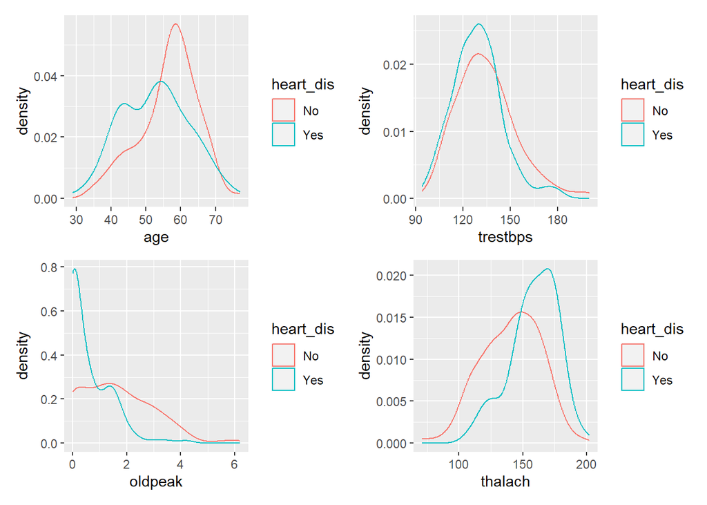

```r
library(ggplot2)
library(patchwork)
#First, make the plot for age predictor
#Color by the two classes of heart disease
p.age<- ggplot(data=Heart.Train, mapping = aes(x=age)) +
   geom_density(aes(color=heart_dis))
#Repeat for trestbps, oldpeak, and thalach predictors
#Once again coloring by the two classes of heart disease in each.
p.trestbps<- ggplot(data=Heart.Train, mapping = aes(x=trestbps)) +
   geom_density(aes(color=heart_dis))
p.oldpeak<- ggplot(data=Heart.Train, mapping = aes(x=oldpeak)) +
   geom_density(aes(color=heart_dis))
p.thalach<- ggplot(data=Heart.Train, mapping = aes(x=thalach)) +
   geom_density(aes(color=heart_dis))
#Plot/show all plots together using patchwork package and +
p.age + p.trestbps + p.oldpeak + p.thalach
```

Use the training data to fit an LDA model using age, sex, cp, trestbps, thalach, exang, oldpeak, ca, and thal as predictors. Use a Bayes classification rule and report both the prediction training accuracy and the prediction test accuracy.

```r
library(MASS) # package containing lda function
#First, fit the model accordingly
m_lda<- lda(target~ age + as.factor(sex) + as.factor(cp) + trestbps +
           thalach+ as.factor(exang) + oldpeak + ca + thal,
           data = Heart.Train)
#Now, use Bayes classification rule to get the following
#Prediction training accuracy
(conf.train_lda<- table(pred=predict(m_lda)$class,
                        true=Heart.Train$target))
```

```
##     true
## pred   0   1
##    0  86  13
##    1  26 118
```

```r
(conf.train_lda[1, 1] + conf.train_lda[2, 2])/sum(conf.train_lda)
```

```
## [1] 0.8395062
```

```r
#Prediction test accuracy
(conf.test_lda <- table(pred = predict(m_lda, newdata = Heart.Test)$class,
                        true = Heart.Test$target))
```

```
##     true
## pred  0  1
##    0 19  4
##    1  7 30
```